# Lecture 12

# Text mining

非結構化的資料 (要將文字轉化為有一定格式的資料，即「結構化」)

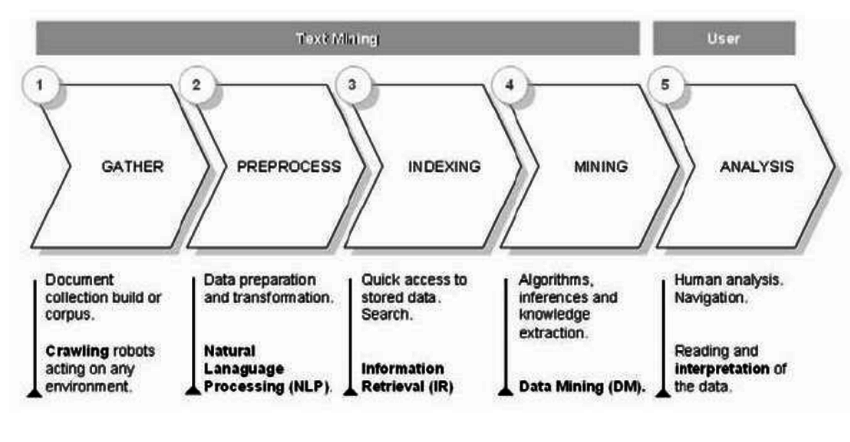

[figure not shown]

一些現成的網站：

opview、蛛思輿情分析平台、意藍資訊、網路溫度計 https://dailyview.tw/

http://blog.pulipuli.info/2017/10/text-analyzer-for-text-mining.html#postcatatext-analyzer-for-text-mining.html0_anchor0

https://everything.shinyapps.io/R-test/?fbclid=IwAR1hVueENjNIV-7juJiNkrX2Yx86DRDv7ISgxP7XVQLKT3-SM9tP2mjYO6A

商業應用：

- 行銷面: 產品創新，商品銷售，品牌定位，購物經驗
- 公關面: 事件推論，危機預警
- 社群操作面: 社群操作，議題操作，Social Network Analysis
- 醫藥面: 找出危險疾病，症狀推論

Easy way：計算每個詞的出現頻率，再應用 Clustering 或者 Classification 的演算法進行關聯性分析或預測

需要「斷詞」。把詞彙以「意義」為單位切割出來。

例如：“我最喜歡上統計系的課”

斷詞：“我 最 喜歡 上 統計系 的 課”

可應用在：文本分析、問答系統、摘要、文件檢索、翻譯、語音辨識、關鍵字分群、主題模型、情緒分析

Example 1: 單一文本，各詞出現次數

| 字 | 頻率 |
| --- | --- |
| 我 | 5 |
| 你 | 3 |
| 他 | 0 |
| 好 | 2 |
| 早 | 1 |

Example 2: 眾多文本，是否有出現這個字

| 文章 | 我 | 你 | 他 | 好 | 早 |
| --- | --- | --- | --- | --- | --- |
| 1 | 1 | 0 | 1 | 1 | 1 |
| 2 | 0 | 0 | 1 | 1 | 1 |
| 3 | 1 | 0 | 1 | 0 | 0 |

Example 3: 眾多文本，出現這個字的頻率

| 文章 | 我 | 你 | 他 | 好 | 早 |
| --- | --- | --- | --- | --- | --- |
| 1 | 5 | 0 | 3 | 4 | 1 |
| 2 | 0 | 0 | 2 | 1 | 1 |
| 3 | 3 | 0 | 6 | 0 | 0 |

- 關連性分析

  提供詞彙之間的關係，輔助辨別文章特性和文章間的關係。用相關係數、相似指數。

  找出資料彼此的關聯性，例如超市中消費者購物欄中的商品間，是否存在明顯的相關性。如果有明顯的相關性，可以作為賣場商品擺設、商品包裝及貨物倉儲之參考。
- 分類分析(classification)

  從文件中依據使用者給予的分類架構，系統根據資料屬性進行自動分類。然後在相同分類下進行分析。 e.g. naive bayes, svm, random forest
- 群集分析(clustering analysis)

  依照資料本身的相似性分成若干群集，使得群集內的資料具有高度同質性。

常用距離

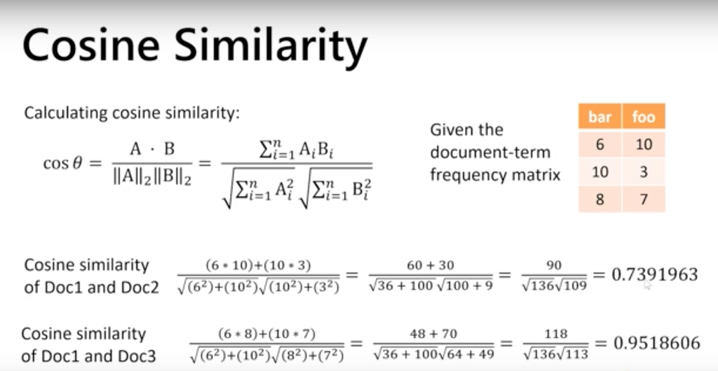

相關Package: `twitteR` provides access to Twitter data, `tm` provides functions for text mining, and `wordcloud` visualizes the result with a word cloud.

http://www.rdatamining.com/examples/text-mining

```
library(tm)
tm包中最重要的格式是Corpus(文集)，就是把一堆文件塞在一起再去處理的一種物件格式，

Corpus(doc), representing a collection of text documents. 建立類似矩陣的文檔的集合

Corpus(DirSource(“C:/Users/.../Documents/doc”)) #get files from doc folder

inspect(doc) 文本查看

tm_map(doc,變形函數)
變形函數包含了：
getTransformations()
"removeNumbers" 去除所有數字
"removePunctuation"  去除標點符號
"removeWords"  去除指定文字 （也可用stopwords() ）
"stemDocument"  提取單詞
"stripWhitespace" 去除多餘空格

詞頻矩陣
DocumentTermMatrix()
TermDocumentMatrix()
findFreqTerms()
findAssocs()
removeSparseTerms()
e.g. For example, a term that appears say just 4 times in a corpus of say size 1000, will have a frequency of appearance of 0.004 =4/1000.

This term's sparsity will be (1000-4)/1000 = 1- 0.004 = 0.996 = 99.6%.
```

https://cran.r-project.org/web/packages/tm/vignettes/tm.pdf

## 中文斷詞套件

```
library("Rwordseg")
segmentCN()
```

無法安裝的請參考 https://blog.csdn.net/sinat_26917383/article/details/50867851

```
library("jiebaR")

# 先建cutter 分詞引擎 `worker() `
cutter = worker()
```

jiebaR 中文分詞介紹 http://qinwenfeng.com/jiebaR/

## 文字雲

https://cosx.org/2016/08/wordcloud2/ https://github.com/lchiffon/wordcloud2

```
install.packages("wordcloud2")
library(wordcloud2)
wordcloud2(data)
```

##Appendix 常用的一些清資料function

```
clean.text = function(x)
{
  # tolower
  x = tolower(x)
  # remove rt
  x = gsub("rt", "", x)
  # remove at
  x = gsub("@\\w+", "", x)
  # remove punctuation
  x = gsub("[[:punct:]]", "", x)
  # remove numbers
  x = gsub("[[:digit:]]", "", x)
  # remove links http
  x = gsub("http\\w+", "", x)
  # remove tabs
  x = gsub("[ |\t]{2,}", "", x)
  # remove blank spaces at the beginning
  x = gsub("^ ", "", x)
  # remove blank spaces at the end
  x = gsub(" $", "", x)
  return(x)
}
```

## Exercise

1. Read: https://uc-r.github.io/word_relationships